# Практика · Самонаглядове навчання

> Лекція: lecture.html · Тест: quiz.html · Домашнє завдання: homework.html

> ⏱ Зошит передтренує **чотирнадцять** мереж без жодної мітки й навчає ще **шість десятків** маленьких класифікаторів. Заміряно на чотирьох ядрах без відеокарти: **близько чотирьох з половиною хвилин** на завантаженій машині (чистого процесорного часу — дві з половиною). Рахунок іде в один потік: так і швидше, і відтворюваніше.

У лекції ми стверджували шість речей. Тут кожна перетворюється на число.

1. **Замір 1 — чи розвʼязний привід.** Порахуємо, для якої частки фігур поворот визначається однозначно. Виявиться, що для однієї з шести.
2. **Замір 2 — контрастне передтренування** проти навчання з нуля: таблиця «міток × спосіб», три зерна, з розкидом.
3. **Замір 3 — розворот:** на якій кількості міток передтренування перестає вигравати.
4. **Замір 4 — що вивчило тіло** без жодної мітки: точність найближчого сусіда в просторі ознак.
5. **Замір 5 — аугментації вирішують:** заберемо одну й подивимось, скільки це коштує.
6. **Замір 6 — скільки непозначених даних треба:** 300, 1200, 4800.

Плюс власна реалізація втрати **NT-Xent** із перевіркою руками на маленькому прикладі.

**Мережа не потрібна:** усі зображення ми малюємо формулами.

```python
import time
import numpy as np
import torch
import torch.nn as nn
import torch.nn.functional as F

# зерна фіксуємо на самому початку: без них числа нижче не збіжаться з лекцією
torch.manual_seed(0)

# один потік, а не чотири. Мережі тут крихітні, і чотири потоки більше часу
# домовляються між собою, ніж рахують. Друга причина важливіша за швидкість:
# під кількома потоками float-суми йдуть в іншому порядку, і числа пливуть.
torch.set_num_threads(1)

notebook_started = time.perf_counter()

print("torch      :", torch.__version__)
print("numpy      :", np.__version__)
print("потоків CPU:", torch.get_num_threads())
```

```
torch      : 2.10.0+cpu
numpy      : 2.5.1
потоків CPU: 1
```

## 1 · Привід: задача, у якій мітку дає саме зображення

Самонаглядове навчання починається з **приводу** (pretext task) — вигаданої задачі, відповідь на яку відома без людини. Класичний приклад: повернути зображення на 0°, 90°, 180° або 270° і вчити мережу вгадувати кут. Кут ми обрали самі, отже мітка безкоштовна.

Але перш ніж навчати що-небудь, треба відповісти на питання, яке пропускають майже всі туторіали: **чи взагалі має ця задача відповідь на наших даних?**

Намалюємо шість наших фігур і поруч — ті самі фігури, повернуті на 90°.

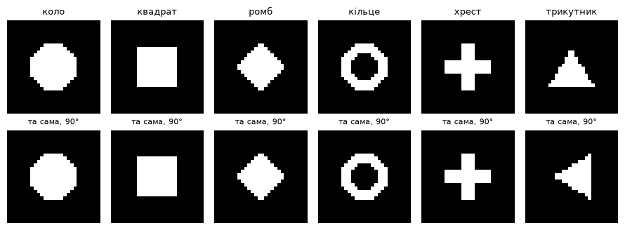

```
верхній рядок — фігура, нижній — вона ж, повернута на 90°
```

```python
SHAPE_NAMES = ["коло", "квадрат", "ромб", "кільце", "хрест", "трикутник"]


def draw_shape(kind, rng, size=28, jitter=5, noise=0.45, center=None, radius=None):
    """Малює одну фігуру як масив 28×28 зі значеннями 0..1.

    center і radius можна задати явно — тоді генератор випадкових чисел не
    потрібен узагалі. Саме так ми зробимо «еталонну» фігуру без шуму й зсуву,
    щоб перевіряти геометрію, а не випадковість.
    """
    image = np.zeros((size, size), dtype=np.float32)
    if center is None:
        center_y = size / 2 + rng.integers(-jitter, jitter + 1)
        center_x = size / 2 + rng.integers(-jitter, jitter + 1)
    else:
        center_y, center_x = center
    if radius is None:
        radius = rng.integers(5, 9)

    # відстані кожного пікселя від центра — з них складаються всі шість фігур
    yy, xx = np.mgrid[0:size, 0:size]
    dy, dx = yy - center_y, xx - center_x

    if kind == 0:                                    # коло
        image[dy * dy + dx * dx <= radius * radius] = 1.0
    elif kind == 1:                                  # квадрат
        image[(np.abs(dy) <= radius * 0.85) & (np.abs(dx) <= radius * 0.85)] = 1.0
    elif kind == 2:                                  # ромб
        image[np.abs(dy) + np.abs(dx) <= radius] = 1.0
    elif kind == 3:                                  # кільце
        distance = dy * dy + dx * dx
        image[(distance <= radius * radius) & (distance >= (radius - 3) ** 2)] = 1.0
    elif kind == 4:                                  # хрест
        image[(np.abs(dy) <= 2) & (np.abs(dx) <= radius)] = 1.0
        image[(np.abs(dx) <= 2) & (np.abs(dy) <= radius)] = 1.0
    else:                                            # трикутник
        image[(dy >= -radius * 0.8) & (dy <= radius * 0.8)
              & (np.abs(dx) <= (dy + radius * 0.8) * 0.6)] = 1.0

    if noise > 0:
        image = image + rng.normal(0, noise, image.shape).astype(np.float32)
    return np.clip(image, 0, 1)


# «еталонні» фігури: рівно по центру, без шуму — тільки геометрія
clean_shapes = [draw_shape(kind, None, center=(13.5, 13.5), radius=7, noise=0.0)
                for kind in range(6)]

import matplotlib.pyplot as plt

figure, axes = plt.subplots(2, 6, figsize=(9, 3.4))
for kind in range(6):
    axes[0, kind].imshow(clean_shapes[kind], cmap="gray")
    axes[0, kind].set_title(SHAPE_NAMES[kind], fontsize=9)
    axes[1, kind].imshow(np.rot90(clean_shapes[kind], 1), cmap="gray")
    axes[1, kind].set_title("та сама, 90°", fontsize=8)
    axes[0, kind].axis("off")
    axes[1, kind].axis("off")
plt.tight_layout()
plt.show()
print("верхній рядок — фігура, нижній — вона ж, повернута на 90°")
```

## 2 · Замір 1: рахуємо, чи розвʼязний привід

Дивитись очима мало — порахуємо. Привід «вгадай кут» має відповідь лише тоді, коли всі чотири повороти зображення **різні між собою**. Якщо повернута фігура збігається з вихідною, то правильної відповіді не існує: одна й та сама картинка є і «0°», і «90°».

Перевіримо три приводи одразу:

- **поворот** — чи всі чотири повороти різні;
- **дзеркало** — чи відрізняється фігура від свого віддзеркалення;
- **квадрант** — чи всі чотири чверті зображення різні між собою (привід «вгадай, звідки вирізано патч»).

```python
def all_different(views):
    """True, якщо всі варіанти попарно різні — тобто відповідь однозначна."""
    for first in range(len(views)):
        for second in range(first + 1, len(views)):
            if np.array_equal(views[first], views[second]):
                return False
    return True


print("%-11s %-12s %-12s %-12s %-12s" %
      ("фігура", "90° = та сама", "180° = та сама", "поворот", "квадрант"))
print("-" * 62)

rotation_solvable = 0
flip_solvable = 0
quadrant_solvable = 0

for kind in range(6):
    image = clean_shapes[kind]
    rotations = [np.rot90(image, k) for k in range(4)]
    quadrants = [image[:14, :14], image[:14, 14:], image[14:, :14], image[14:, 14:]]

    same_after_90 = np.array_equal(image, rotations[1])
    same_after_180 = np.array_equal(image, rotations[2])
    rotation_ok = all_different(rotations)
    flip_ok = not np.array_equal(image, np.fliplr(image))
    quadrant_ok = all_different(quadrants)

    rotation_solvable += rotation_ok
    flip_solvable += flip_ok
    quadrant_solvable += quadrant_ok

    print("%-11s %-12s %-12s %-12s %-12s" %
          (SHAPE_NAMES[kind],
           "так" if same_after_90 else "ні",
           "так" if same_after_180 else "ні",
           "однозначно" if rotation_ok else "НЕМАЄ ВІДПОВІДІ",
           "однозначно" if quadrant_ok else "НЕМАЄ ВІДПОВІДІ"))

print()
print("частка фігур, для яких привід розвʼязний:")
print("  поворот  : %.3f  (%d із 6)" % (rotation_solvable / 6, rotation_solvable))
print("  дзеркало : %.3f  (%d із 6)" % (flip_solvable / 6, flip_solvable))
print("  квадрант : %.3f  (%d із 6)" % (quadrant_solvable / 6, quadrant_solvable))
```

```
фігура      90° = та сама 180° = та сама поворот      квадрант
--------------------------------------------------------------
коло        так          так          НЕМАЄ ВІДПОВІДІ однозначно
квадрат     так          так          НЕМАЄ ВІДПОВІДІ однозначно
ромб        так          так          НЕМАЄ ВІДПОВІДІ однозначно
кільце      так          так          НЕМАЄ ВІДПОВІДІ однозначно
хрест       так          так          НЕМАЄ ВІДПОВІДІ однозначно
трикутник   ні           ні           однозначно   однозначно

частка фігур, для яких привід розвʼязний:
  поворот  : 0.167  (1 із 6)
  дзеркало : 0.000  (0 із 6)
  квадрант : 1.000  (6 із 6)
```

Ось і відповідь. Привід «вгадай поворот» розвʼязний рівно для **однієї фігури з шести** — для трикутника. Привід «вгадай дзеркало» не розвʼязний **узагалі ні для однієї**: всі шість наших фігур симетричні відносно вертикалі. А привід «вгадай квадрант» розвʼязний для всіх шести — чверті зображення різні навіть у кола, бо чверть кола з отвором угору-ліворуч не дорівнює чверті з отвором угору-праворуч.

Це не дрібниця й не особливість саме наших фігур. Це **обовʼязкова перевірка перед будь-яким приводом**: якщо для більшості твоїх даних правильної відповіді не існує, мережа не вивчить нічого — вона просто знайде обхідний шлях.

## 3 · Датасет

Далі йде наскрізний приклад теми: ті самі шість фігур, але вже з випадковим зсувом центра (±5 пікселів) і шумом σ = 0.45.

- **4800 непозначених** зображень — на них іде передтренування; міток ми не торкаємось;
- **300 позначених** — з них братимемо 30, 60, 120 або 300 прикладів;
- **600 для перевірки**.

```python
def make_dataset(count, rng):
    """Повертає (count, 1, 28, 28) і (count,). Класів шість, порівну."""
    images = np.zeros((count, 1, 28, 28), dtype=np.float32)
    labels = np.zeros(count, dtype=np.int64)
    for i in range(count):
        kind = i % 6                       # рівно по шостій частині кожного класу
        images[i, 0] = draw_shape(kind, rng)
        labels[i] = kind
    return torch.from_numpy(images), torch.from_numpy(labels)


rng = np.random.default_rng(42)
x_unlabeled, _ = make_dataset(4800, rng)      # мітки є, але ми ними НЕ користуємось
x_pool, y_pool = make_dataset(300, rng)
x_test, y_test = make_dataset(600, rng)

print("непозначених :", tuple(x_unlabeled.shape))
print("позначений пул:", tuple(x_pool.shape), " класів:", len(set(y_pool.tolist())))
print("перевірка     :", tuple(x_test.shape))
print("рівень вгадування на шести класах: %.3f" % (1 / 6))
```

```
непозначених : (4800, 1, 28, 28)
позначений пул: (300, 1, 28, 28)  класів: 6
перевірка     : (600, 1, 28, 28)
рівень вгадування на шести класах: 0.167
```

## 4 · Дешевий обхід: чому «різні пікселі» не означає «розвʼязно»

Тепер важлива пастка. Якщо взяти сирі зображення датасету — зі зсувом і шумом — і спитати, чи відрізняється зображення від свого повороту, відповідь буде «так» практично завжди. Шум і зсув центра роблять будь-які дві картинки різними.

Але це **не** означає, що привід став осмисленим. Мережа справді зможе вгадувати кут — за зсувом центра й за візерунком шуму, а не за формою фігури. Вона навчиться рівно нічого корисного. Порахуємо цю оманливу частку.

```python
rotation_looks_solvable = 0
for i in range(300):
    image = x_unlabeled[i, 0].numpy()
    if not np.array_equal(image, np.rot90(image, 1)):
        rotation_looks_solvable += 1

print("на сирих зображеннях поворот «помітний» у %.3f випадків"
      % (rotation_looks_solvable / 300))
print("на чистій геометрії фігури — лише в %.3f" % (rotation_solvable / 6))
print()
print("різниця між цими двома числами і є та дірка, у яку провалюється привід:")
print("мережа розвʼязує задачу за шумом і зсувом, а не за формою.")
```

```
на сирих зображеннях поворот «помітний» у 1.000 випадків
на чистій геометрії фігури — лише в 0.167

різниця між цими двома числами і є та дірка, у яку провалюється привід:
мережа розвʼязує задачу за шумом і зсувом, а не за формою.
```

## 5 · Мережа: тіло й голова

Мережа та сама, що в темі «Перенос навчання»: три блоки `Conv → ReLU → Pool`, які перетворюють 28×28 на 288 чисел, і голова, яка ухвалює рішення.

Нове тут одне — **проєктор** (projection head). Під час контрастного навчання ми порівнюємо не самі 288 чисел, а їхнє стиснення до 32. Так робить SimCLR, і причина проста: втрата тягне свій вихід у дуже специфічний бік, і краще, щоб вона робила це з окремим шматком мережі, який ми потім викинемо. Лишиться тіло — воно й цінне.

```python
def conv_block(in_channels, out_channels):
    """Один типовий блок: Conv → ReLU → Pool."""
    return nn.Sequential(
        nn.Conv2d(in_channels, out_channels, kernel_size=3, padding=1),
        nn.ReLU(),
        nn.MaxPool2d(2),
    )


class Body(nn.Module):
    """Тіло: 1×28×28 → 288 чисел (32 канали по 3×3)."""

    def __init__(self):
        super().__init__()
        self.net = nn.Sequential(
            conv_block(1, 8),        # 1×28×28  →  8×14×14
            conv_block(8, 16),       # 8×14×14  → 16×7×7
            conv_block(16, 32),      # 16×7×7   → 32×3×3
            nn.Flatten(),
        )

    def forward(self, x):
        return self.net(x)


class Projector(nn.Module):
    """Тимчасова надбудова для контрастної втрати: 288 → 64 → 32. Потім викидається."""

    def __init__(self, dim=32):
        super().__init__()
        self.net = nn.Sequential(nn.Linear(288, 64), nn.ReLU(), nn.Linear(64, dim))

    def forward(self, x):
        return self.net(x)


class ShapeNet(nn.Module):
    """Тіло плюс голова — звичайний класифікатор."""

    def __init__(self, n_classes=6):
        super().__init__()
        self.body = Body()
        self.head = nn.Linear(288, n_classes)

    def forward(self, x):
        return self.head(self.body(x))


torch.manual_seed(0)
probe_model = ShapeNet(6)
body_params = sum(p.numel() for p in probe_model.body.parameters())
head_params = sum(p.numel() for p in probe_model.head.parameters())

# голова — це рівно 288×6 ваг плюс 6 зсувів; порахуємо руками й звіримо
head_by_hand = 288 * 6 + 6
assert head_params == head_by_hand, "рахунок голови розійшовся!"

print("параметрів у тілі  :", body_params)
print("параметрів у голові:", head_params, " рукою:", head_by_hand, "✅ збігається")
print("тіло тримає %.0f%% усіх ваг" % (100 * body_params / (body_params + head_params)))
```

```
параметрів у тілі  : 5888
параметрів у голові: 1734  рукою: 1734 ✅ збігається
тіло тримає 77% усіх ваг
```

## 6 · Чому датасет саме такий складний

Одна деталь, без якої весь замір був би порожнім. Наші фігури можна зробити чистішими — шум 0.20 замість 0.45, зсув ±4 замість ±5. І тоді вимірювати буде нічого: **навіть випадкове, ніяк не навчене тіло** розділяє класи майже добре.

Перевіримо це прямо. Візьмемо непідготовлену мережу з випадковими вагами, прогонимо через неї зображення й подивимось, чи достатньо близько лежать сусіди одного класу. Міра — точність найближчого сусіда (`kNN`) у просторі ознак: для кожного тестового зображення шукаємо найсхожіше з відомих і беремо його клас.

```python
@torch.no_grad()
def knn_accuracy(body, x_bank, y_bank, x_query, y_query):
    """Точність найближчого сусіда в просторі ознак — навчання з мітками НЕ потрібне.

    Ознаки нормуємо на довжину 1, тоді скалярний добуток — це косинус кута між
    ними, тобто пряма міра «наскільки два зображення схожі очима мережі».
    """
    body.eval()
    bank = F.normalize(body(x_bank), dim=1)
    query = F.normalize(body(x_query), dim=1)
    similarity = query @ bank.t()
    nearest = similarity.argmax(dim=1)
    return (y_bank[nearest] == y_query).float().mean().item()


def make_easy_dataset(count, rng):
    """Той самий генератор, але з мʼякшими налаштуваннями: шум 0.20, зсув ±4."""
    images = np.zeros((count, 1, 28, 28), dtype=np.float32)
    labels = np.zeros(count, dtype=np.int64)
    for i in range(count):
        kind = i % 6
        images[i, 0] = draw_shape(kind, rng, jitter=4, noise=0.20)
        labels[i] = kind
    return torch.from_numpy(images), torch.from_numpy(labels)


easy_rng = np.random.default_rng(7)
easy_pool_x, easy_pool_y = make_easy_dataset(300, easy_rng)
easy_test_x, easy_test_y = make_easy_dataset(600, easy_rng)

torch.manual_seed(7)
easy_knn = knn_accuracy(Body(), easy_pool_x, easy_pool_y, easy_test_x, easy_test_y)
torch.manual_seed(7)
hard_knn = knn_accuracy(Body(), x_pool, y_pool, x_test, y_test)

print("kNN на ВИПАДКОВОМУ (не навченому) тілі:")
print("  легкі фігури (шум 0.20, зсув ±4): %.3f" % easy_knn)
print("  наші фігури  (шум 0.45, зсув ±5): %.3f" % hard_knn)
print("  рівень вгадування               : %.3f" % (1 / 6))
print()
print("на легких фігурах випадкова згортка вже майже розвʼязує задачу —")
print("передтренуванню не лишилось би що покращувати. Тому беремо складніші.")
```

```
kNN на ВИПАДКОВОМУ (не навченому) тілі:
  легкі фігури (шум 0.20, зсув ±4): 0.690
  наші фігури  (шум 0.45, зсув ±5): 0.442
  рівень вгадування               : 0.167

на легких фігурах випадкова згортка вже майже розвʼязує задачу —
передтренуванню не лишилось би що покращувати. Тому беремо складніші.
```

## 7 · Два види одного зображення

Контрастне навчання не вгадує нічого про зображення. Воно робить простішу річ: бере одне зображення, псує його **двічі по-різному** й вимагає, щоб мережа впізнала в цих двох виглядах те саме.

Аугментації тут — не косметика, а **сама постановка задачі**. Кожна аугментація — це заява «оце міняти можна, клас від цього не змінюється». Тому серед них немає повороту: ми щойно порахували, що поворот наших фігур не міняє, і зближувати повернуті види означало б вчити мережу ігнорувати те, чого вона й так не бачить.

Беремо три: **зсув** (±3 пікселі), **яскравість і контраст**, **додатковий шум**.

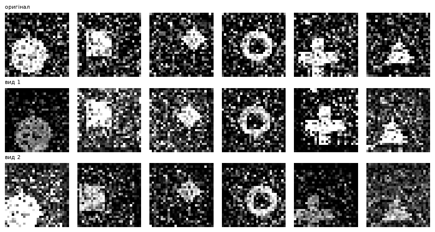

```
два нижні рядки — той самий предмет. Мережа має це зрозуміти сама.
```

```python
def augment(x, generator, shift=True, brightness=True, noise=True, max_shift=3):
    """Випадковий вигляд партії зображень. Жодна операція не міняє клас фігури."""
    n = x.shape[0]
    out = x

    if shift:
        # доповнюємо кадр нулями й вирізаємо вікно 28×28 у випадковому місці
        padded = F.pad(out, (max_shift, max_shift, max_shift, max_shift))
        offset_y = torch.randint(0, 2 * max_shift + 1, (n,), generator=generator)
        offset_x = torch.randint(0, 2 * max_shift + 1, (n,), generator=generator)
        moved = torch.empty_like(out)
        for i in range(n):
            moved[i] = padded[i, :, offset_y[i]:offset_y[i] + 28,
                              offset_x[i]:offset_x[i] + 28]
        out = moved

    if brightness:
        # множник міняє контраст, доданок — загальну яскравість
        gain = 0.6 + 0.8 * torch.rand(n, 1, 1, 1, generator=generator)
        bias = -0.15 + 0.3 * torch.rand(n, 1, 1, 1, generator=generator)
        out = out * gain + bias

    if noise:
        out = out + 0.15 * torch.randn(out.shape, generator=generator)

    return out.clamp(0, 1)


views_generator = torch.Generator().manual_seed(5)
sample = x_pool[:6]
view_one = augment(sample, views_generator)
view_two = augment(sample, views_generator)

figure, axes = plt.subplots(3, 6, figsize=(9, 4.8))
for slot in range(6):
    axes[0, slot].imshow(sample[slot, 0], cmap="gray", vmin=0, vmax=1)
    axes[1, slot].imshow(view_one[slot, 0], cmap="gray", vmin=0, vmax=1)
    axes[2, slot].imshow(view_two[slot, 0], cmap="gray", vmin=0, vmax=1)
    for row in range(3):
        axes[row, slot].axis("off")
axes[0, 0].set_title("оригінал", fontsize=8, loc="left")
axes[1, 0].set_title("вид 1", fontsize=8, loc="left")
axes[2, 0].set_title("вид 2", fontsize=8, loc="left")
plt.tight_layout()
plt.show()
print("два нижні рядки — той самий предмет. Мережа має це зрозуміти сама.")
```

## 8 · NT-Xent: пишемо втрату самі й перевіряємо руками

Тепер головна формула теми. У партії з N зображень ми зробили 2N видів. Для кожного виду є рівно **один свій** (другий вид того самого зображення) і 2N−2 чужих. Втрата вимагає: свій має бути схожішим за всіх чужих.

Для одного виду з номером i:

втрата(i) = −log( exp(s(i, свій)/τ) / Σ<sub>j≠i</sub> exp(s(i, j)/τ) )

де s(a, b) — косинусна схожість двох векторів (від −1 до 1), τ — температура, а Σ (грецька сигма) означає «додай усе, що йде далі». У чисельнику стоїть **свій**, у знаменнику — **усі, крім себе самого**. Мінус логарифм перетворює «хочу, щоб частка була близька до 1» на «хочу, щоб число було близьке до 0».

Спершу напишемо це матрицями, потім порахуємо той самий вираз у лоб, циклом, і звіримо. Якщо збіглося — реалізація правильна.

```python
def nt_xent(z_one, z_two, temperature=0.1):
    """Контрастна втрата NT-Xent для двох наборів видів однієї партії."""
    n = z_one.shape[0]

    # нормуємо на довжину 1: після цього скалярний добуток дорівнює косинусу кута
    z = F.normalize(torch.cat([z_one, z_two], dim=0), dim=1)

    similarity = z @ z.t() / temperature
    # себе з собою не порівнюємо: інакше «свій» завжди програвав би самому собі
    similarity.fill_diagonal_(-1e9)

    # для виду i з першої половини свій — це i+n, для виду з другої — i−n
    partner = torch.cat([torch.arange(n, 2 * n), torch.arange(0, n)])
    return F.cross_entropy(similarity, partner)


# ---- перевірка руками на партії з трьох зображень ----
torch.manual_seed(0)
demo_one = torch.randn(3, 4)
demo_two = torch.randn(3, 4)
library_value = nt_xent(demo_one, demo_two, temperature=0.5)

# той самий вираз у лоб, без жодних матричних трюків
demo_z = F.normalize(torch.cat([demo_one, demo_two], dim=0), dim=1)
total = 0.0
for i in range(6):
    partner_index = i + 3 if i < 3 else i - 3
    numerator = torch.exp(demo_z[i] @ demo_z[partner_index] / 0.5)
    denominator = 0.0
    for j in range(6):
        if j != i:
            denominator = denominator + torch.exp(demo_z[i] @ demo_z[j] / 0.5)
    total = total + (-torch.log(numerator / denominator))
by_hand_value = total / 6

print("наша реалізація : %.6f" % library_value.item())
print("рахунок руками  : %.6f" % by_hand_value.item())
assert torch.allclose(library_value, by_hand_value, atol=1e-6), "розрахунок розійшовся!"
print("✅ збігається")

# і ще одна перевірка сенсу: якщо два види ідентичні, втрата має бути малою
identical = torch.randn(8, 4)
print()
print("втрата, коли види збігаються ідеально: %.3f" % nt_xent(identical, identical, 0.1).item())
print("втрата на випадкових векторах        : %.3f"
      % nt_xent(torch.randn(8, 4), torch.randn(8, 4), 0.1).item())
print("рівень «нічого не знаю» = log(2N−1) = %.3f" % np.log(2 * 8 - 1))
```

```
наша реалізація : 2.351308
рахунок руками  : 2.351308
✅ збігається

втрата, коли види збігаються ідеально: 0.559
втрата на випадкових векторах        : 12.044
рівень «нічого не знаю» = log(2N−1) = 2.708
```

## 9 · Передтренування без жодної мітки

Тепер сам цикл. Він нічим не відрізняється від звичайного навчання, крім одного: `y` тут немає взагалі. Партію беремо, робимо два види, рахуємо NT-Xent, крок.

Партія навмисно велика — 256. Контрастна втрата тим змістовніша, чим більше в знаменнику чужих прикладів: при партії 8 мережі треба відрізнити свій вид від 14 чужих, при 256 — від 510.

Три зерна, бо одне число нічого не варте без розкиду.

```python
PRETRAIN_EPOCHS = 4
BATCH = 256
TEMPERATURE = 0.1
SEEDS = (0, 1, 2)


def pretrain_contrastive(x_unlabeled_part, epochs=PRETRAIN_EPOCHS, batch=BATCH,
                         lr=3e-3, seed=0, temperature=TEMPERATURE, aug_kwargs=None):
    """Вчить тіло без міток: два види одного зображення мають зійтися."""
    if aug_kwargs is None:
        aug_kwargs = {}
    torch.manual_seed(seed)
    body = Body()
    projector = Projector()
    optimizer = torch.optim.Adam(list(body.parameters()) + list(projector.parameters()),
                                 lr=lr)
    generator = torch.Generator().manual_seed(seed + 1000)

    losses = []
    count = len(x_unlabeled_part)
    body.train()
    for _ in range(epochs):
        order = torch.randperm(count, generator=generator)
        epoch_loss, steps = 0.0, 0
        for start in range(0, count, batch):
            index = order[start:start + batch]
            if len(index) < 8:                # надто мала партія знаменник не наповнить
                continue
            images = x_unlabeled_part[index]
            first = augment(images, generator, **aug_kwargs)
            second = augment(images, generator, **aug_kwargs)
            optimizer.zero_grad()
            loss = nt_xent(projector(body(first)), projector(body(second)), temperature)
            loss.backward()
            optimizer.step()
            epoch_loss += loss.item()
            steps += 1
        losses.append(epoch_loss / max(steps, 1))
    return body, losses


contrastive_bodies = {}
print("передтренування: епох %d, партія %d, температура %.2f, непозначених %d"
      % (PRETRAIN_EPOCHS, BATCH, TEMPERATURE, len(x_unlabeled)))
print("рівень «нічого не знаю» для втрати = log(2·%d−1) = %.3f" % (BATCH, np.log(2 * BATCH - 1)))
print()
for seed in SEEDS:
    started = time.perf_counter()
    body, losses = pretrain_contrastive(x_unlabeled, seed=seed)
    contrastive_bodies[seed] = body
    print("зерно %d: %4.0f с   втрата %.3f → %.3f   kNN тіла %.3f"
          % (seed, time.perf_counter() - started, losses[0], losses[-1],
             knn_accuracy(body, x_pool, y_pool, x_test, y_test)))
```

```
передтренування: епох 4, партія 256, температура 0.10, непозначених 4800
рівень «нічого не знаю» для втрати = log(2·256−1) = 6.236
```

```
зерно 0:   19 с   втрата 5.584 → 3.852   kNN тіла 0.508
```

```
зерно 1:   14 с   втрата 5.458 → 4.168   kNN тіла 0.493
```

```
зерно 2:   14 с   втрата 5.542 → 3.891   kNN тіла 0.490
```

## 10 · Той самий бюджет, але привід «вгадай поворот»

Щоб порівняння було чесним, повторимо все з нерозвʼязним приводом: ті самі 4800 непозначених зображень, ті самі епохи, ті самі зерна. Мережа отримує повернуте зображення й має назвати кут — задача з чотирма відповідями, вгадування дає 0.25.

```python
def pretrain_rotation(x_unlabeled_part, epochs=PRETRAIN_EPOCHS, batch=BATCH, lr=3e-3, seed=0):
    """Вироджений привід: вгадай кут повороту 0/90/180/270."""
    torch.manual_seed(seed)
    body = Body()
    head = nn.Linear(288, 4)
    optimizer = torch.optim.Adam(list(body.parameters()) + list(head.parameters()), lr=lr)
    generator = torch.Generator().manual_seed(seed + 1000)

    count = len(x_unlabeled_part)
    accuracies = []
    body.train()
    for _ in range(epochs):
        order = torch.randperm(count, generator=generator)
        right, total = 0, 0
        for start in range(0, count, batch):
            index = order[start:start + batch]
            if len(index) < 8:
                continue
            images = x_unlabeled_part[index]
            turns = torch.randint(0, 4, (len(index),), generator=generator)
            # мітка береться з самої операції: ми ж і вирішили, на скільки крутити
            turned = torch.stack([torch.rot90(images[i], int(turns[i]), dims=(1, 2))
                                  for i in range(len(index))])
            optimizer.zero_grad()
            logits = head(body(turned))
            loss = F.cross_entropy(logits, turns)
            loss.backward()
            optimizer.step()
            right += (logits.argmax(1) == turns).sum().item()
            total += len(index)
        accuracies.append(right / max(total, 1))
    return body, accuracies


rotation_bodies = {}
print("привід «вгадай поворот», вгадування дає 0.250")
print()
for seed in SEEDS:
    started = time.perf_counter()
    body, accuracies = pretrain_rotation(x_unlabeled, seed=seed)
    rotation_bodies[seed] = body
    print("зерно %d: %4.0f с   точність приводу %.3f → %.3f   kNN тіла %.3f"
          % (seed, time.perf_counter() - started, accuracies[0], accuracies[-1],
             knn_accuracy(body, x_pool, y_pool, x_test, y_test)))
```

```
привід «вгадай поворот», вгадування дає 0.250
```

```
зерно 0:    6 с   точність приводу 0.275 → 0.316   kNN тіла 0.405
```

```
зерно 1:    7 с   точність приводу 0.273 → 0.326   kNN тіла 0.447
```

```
зерно 2:    8 с   точність приводу 0.286 → 0.321   kNN тіла 0.418
```

## 11 · Замір 4: що вивчило тіло, поки не бачило жодної мітки

Найпряміше питання теми. У нас є тіло, яке ніколи не бачило слова «трикутник». Чи розкладає воно фігури по різних кутках свого простору ознак?

Перевірка не вимагає жодного навчання: беремо 300 зображень із відомими класами як довідник, для кожного тестового шукаємо найсхожіше й дивимось, чи збігся клас. Порівнюємо три тіла: контрастне, «поворотне» і **зовсім випадкове**.

Випадкове тіло тут — не жарт, а обовʼязкова точка відліку. Згорткова мережа з випадковими вагами вже щось робить із зображенням, і без цього рядка легко приписати передтренуванню чужу заслугу.

```python
knn_results = {}
for name, bodies in (("контрастне", contrastive_bodies), ("поворот", rotation_bodies)):
    values = [knn_accuracy(bodies[seed], x_pool, y_pool, x_test, y_test) for seed in SEEDS]
    knn_results[name] = (float(np.mean(values)), float(np.std(values)))

random_values = []
for seed in SEEDS:
    torch.manual_seed(100 + seed)
    random_values.append(knn_accuracy(Body(), x_pool, y_pool, x_test, y_test))
knn_results["випадкове"] = (float(np.mean(random_values)), float(np.std(random_values)))

print("%-14s %s" % ("тіло", "kNN у просторі ознак (3 зерна)"))
print("-" * 46)
for name in ("випадкове", "поворот", "контрастне"):
    mean, spread = knn_results[name]
    print("%-14s %.3f ±%.3f" % (name, mean, spread))
print("%-14s %.3f" % ("вгадування", 1 / 6))
```

```
тіло           kNN у просторі ознак (3 зерна)
----------------------------------------------
випадкове      0.411 ±0.007
поворот        0.423 ±0.017
контрастне     0.497 ±0.008
вгадування     0.167
```

Подивимось на це очима. Візьмемо 288 чисел, які тіло видає на 180 зображеннях, і стиснемо їх до двох вимірів методом головних компонент (PCA — він шукає два напрямки, уздовж яких хмара точок розтягнута найбільше). Точки фарбуємо **справжнім класом**, якого тіло не бачило. Три панелі — три тіла: випадкове, після нерозвʼязного приводу й після контрастного навчання.

Заразом надрукуємо, яку частку всього розкиду вміщують ці дві осі. Тут чекає пастка, на яку варто подивитись самому: більша частка **не** означає кращого представлення.

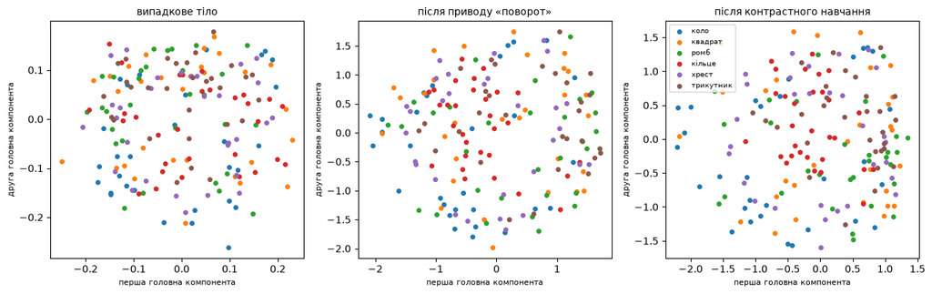

```
дві компоненти пояснюють розкиду:
  випадкове тіло : 31.7 %
  привід поворот : 67.6 %
  контрастне     : 55.5 %

велика частка сама собою нічого не варта: у «поворотного» тіла вона найбільша,
а класи в ньому не розділяються (kNN 0.423 проти 0.497 у контрастного).
```

```python
def pca_two_dimensions(features):
    """Дві головні компоненти плюс частка розкиду, яку вони пояснюють."""
    centered = features - features.mean(axis=0)
    _, singular, directions = np.linalg.svd(centered, full_matrices=False)
    coordinates = centered @ directions[:2].T
    explained = float((singular[:2] ** 2).sum() / (singular ** 2).sum())
    return coordinates, explained


with torch.no_grad():
    contrastive_bodies[0].eval()
    contrastive_features = contrastive_bodies[0](x_pool[:180]).numpy()
    rotation_bodies[0].eval()
    rotation_features = rotation_bodies[0](x_pool[:180]).numpy()
    torch.manual_seed(100)
    untrained_body = Body()
    untrained_body.eval()
    random_features = untrained_body(x_pool[:180]).numpy()

contrastive_xy, contrastive_share = pca_two_dimensions(contrastive_features)
rotation_xy, rotation_share = pca_two_dimensions(rotation_features)
random_xy, random_share = pca_two_dimensions(random_features)
true_labels = y_pool[:180].numpy()

figure, axes = plt.subplots(1, 3, figsize=(13, 4.2))
for axis, coordinates, title in ((axes[0], random_xy, "випадкове тіло"),
                                 (axes[1], rotation_xy, "після приводу «поворот»"),
                                 (axes[2], contrastive_xy, "після контрастного навчання")):
    for kind in range(6):
        mask = true_labels == kind
        axis.scatter(coordinates[mask, 0], coordinates[mask, 1], s=16,
                     label=SHAPE_NAMES[kind])
    axis.set_title(title, fontsize=10)
    axis.set_xlabel("перша головна компонента", fontsize=8)
    axis.set_ylabel("друга головна компонента", fontsize=8)
axes[2].legend(fontsize=7, loc="best")
plt.tight_layout()
plt.show()

print("дві компоненти пояснюють розкиду:")
print("  випадкове тіло : %.1f %%" % (100 * random_share))
print("  привід поворот : %.1f %%" % (100 * rotation_share))
print("  контрастне     : %.1f %%" % (100 * contrastive_share))
print()
print("велика частка сама собою нічого не варта: у «поворотного» тіла вона найбільша,")
print("а класи в ньому не розділяються (kNN %.3f проти %.3f у контрастного)."
      % (knn_results["поворот"][0], knn_results["контрастне"][0]))
```

## 12 · Три способи скористатися тілом

Далі — механіка з теми «Перенос навчання», без змін:

| Спосіб | Тіло | Що вчиться |
| --- | --- | --- |
| З нуля | випадкове | усе |
| Лінійна проба | передтреноване, заморожене | лише лінійний шар 288 → 6 |
| Донавчання | передтреноване, вільне | усе |

Лінійна проба — головна міра якості представлення. Якщо класи розділяються **однією прямою** в просторі ознак, значить тіло вже зробило найважчу частину роботи.

```python
def train_classifier(model, x, y, epochs=25, lr=3e-3, batch=8, seed=0, params=None):
    """Звичайне навчання з мітками. params=None означає «вчити все, що є»."""
    torch.manual_seed(seed)
    optimizer = torch.optim.Adam(
        params if params is not None else model.parameters(), lr=lr)
    loss_function = nn.CrossEntropyLoss()
    model.train()
    for _ in range(epochs):
        order = torch.randperm(len(x))
        for start in range(0, len(x), batch):
            index = order[start:start + batch]
            optimizer.zero_grad()
            loss = loss_function(model(x[index]), y[index])
            loss.backward()
            optimizer.step()
    return model


@torch.no_grad()
def accuracy(model, x, y):
    model.eval()
    return (model(x).argmax(1) == y).float().mean().item()


def train_from_scratch(x, y, seed=0):
    """Жодного знання ззовні: тіло випадкове, вчиться все."""
    torch.manual_seed(seed)
    model = ShapeNet(6)
    train_classifier(model, x, y, seed=seed)
    return accuracy(model, x_test, y_test)


def linear_probe(body_state, x, y, seed=0):
    """Тіло заморожене, вчиться лише лінійний шар — міра якості представлення."""
    torch.manual_seed(seed)
    model = ShapeNet(6)
    model.body.load_state_dict(body_state)
    for parameter in model.body.parameters():
        parameter.requires_grad = False
    train_classifier(model, x, y, seed=seed, params=list(model.head.parameters()))
    return accuracy(model, x_test, y_test)


def finetune(body_state, x, y, seed=0):
    """Тіло передтреноване, але вільне: вчиться все."""
    torch.manual_seed(seed)
    model = ShapeNet(6)
    model.body.load_state_dict(body_state)
    train_classifier(model, x, y, seed=seed)
    return accuracy(model, x_test, y_test)


torch.manual_seed(0)
demo = ShapeNet(6)
for parameter in demo.body.parameters():
    parameter.requires_grad = False
print("вільних чисел при лінійній пробі :",
      sum(p.numel() for p in demo.parameters() if p.requires_grad))
print("вільних чисел при донавчанні     :", sum(p.numel() for p in ShapeNet(6).parameters()))
```

```
вільних чисел при лінійній пробі : 1734
вільних чисел при донавчанні     : 7622
```

## 13 · Заміри 2 і 3: таблиця «міток × спосіб»

Головний замір теми. Чотири кількості міток, чотири способи, три зерна. Це найдовша клітинка зошита — **близько півтори хвилини**.

```python
LABEL_COUNTS = (30, 60, 120, 300)
results = {}

print("%-7s %-16s %-16s %-16s %-16s"
      % ("міток", "з нуля", "проба (контр.)", "донавч. (контр.)", "проба (поворот)"))
print("-" * 76)

for count in LABEL_COUNTS:
    x_part, y_part = x_pool[:count], y_pool[:count]
    row = {}

    values = [train_from_scratch(x_part, y_part, seed=s) for s in SEEDS]
    row["scratch"] = (float(np.mean(values)), float(np.std(values)))

    values = [linear_probe(contrastive_bodies[s].state_dict(), x_part, y_part, seed=s)
              for s in SEEDS]
    row["probe"] = (float(np.mean(values)), float(np.std(values)))

    values = [finetune(contrastive_bodies[s].state_dict(), x_part, y_part, seed=s)
              for s in SEEDS]
    row["finetune"] = (float(np.mean(values)), float(np.std(values)))

    values = [linear_probe(rotation_bodies[s].state_dict(), x_part, y_part, seed=s)
              for s in SEEDS]
    row["rotation_probe"] = (float(np.mean(values)), float(np.std(values)))

    results[count] = row
    print("%-7d %.3f ±%.3f     %.3f ±%.3f     %.3f ±%.3f     %.3f ±%.3f"
          % (count, *row["scratch"], *row["probe"], *row["finetune"], *row["rotation_probe"]))

print()
print("рівень вгадування: %.3f" % (1 / 6))
```

```
міток   з нуля           проба (контр.)   донавч. (контр.) проба (поворот)
----------------------------------------------------------------------------
```

```
30      0.339 ±0.014     0.372 ±0.030     0.369 ±0.013     0.237 ±0.014
```

```
60      0.427 ±0.003     0.407 ±0.025     0.454 ±0.020     0.248 ±0.024
```

```
120     0.524 ±0.020     0.418 ±0.010     0.504 ±0.020     0.298 ±0.023
```

```
300     0.702 ±0.024     0.451 ±0.026     0.737 ±0.034     0.416 ±0.024

рівень вгадування: 0.167
```

Тепер витягнемо з таблиці головне: **де проходить розворот**. Порівняємо лінійну пробу з навчанням з нуля на кожній кількості міток.

```python
print("%-7s %-10s %-10s %-12s" % ("міток", "з нуля", "проба", "хто виграв"))
print("-" * 44)
crossover = None
for count in LABEL_COUNTS:
    scratch = results[count]["scratch"][0]
    probe = results[count]["probe"][0]
    winner = "проба" if probe > scratch else "з нуля"
    if probe <= scratch and crossover is None:
        crossover = count
    print("%-7d %-10.3f %-10.3f %-12s (різниця %+.3f)"
          % (count, scratch, probe, winner, probe - scratch))

print()
print("самонаглядове передтренування перестає вигравати на %d мітках" % crossover)
print()
print("а ось що дав нерозвʼязний привід (поворот) — порівняно з навчанням з нуля:")
for count in LABEL_COUNTS:
    print("  %3d міток: поворот %.3f проти %.3f з нуля  (%+.3f)"
          % (count, results[count]["rotation_probe"][0], results[count]["scratch"][0],
             results[count]["rotation_probe"][0] - results[count]["scratch"][0]))
```

```
міток   з нуля     проба      хто виграв
--------------------------------------------
30      0.339      0.372      проба        (різниця +0.033)
60      0.427      0.407      з нуля       (різниця -0.019)
120     0.524      0.418      з нуля       (різниця -0.106)
300     0.702      0.451      з нуля       (різниця -0.251)

самонаглядове передтренування перестає вигравати на 60 мітках

а ось що дав нерозвʼязний привід (поворот) — порівняно з навчанням з нуля:
   30 міток: поворот 0.237 проти 0.339 з нуля  (-0.102)
   60 міток: поворот 0.248 проти 0.427 з нуля  (-0.179)
  120 міток: поворот 0.298 проти 0.524 з нуля  (-0.226)
  300 міток: поворот 0.416 проти 0.702 з нуля  (-0.286)
```

## 14 · Замір 5: аугментації — це і є задача

Контрастна мережа вчиться **рівно тому, що ти оголосив неістотним**. Заберемо зсув із набору аугментацій. Тоді два види одного зображення відрізнятимуться лише яскравістю й шумом, а фігура лишатиметься на місці — і мережі стане вигідно впізнавати види за **положенням**, а не за формою.

Для контролю заберемо натомість яскравість. Два зерна на конфігурацію.

```python
ablation = {}
ablation["повний набір"] = (results[60]["probe"][0], results[30]["probe"][0],
                            knn_results["контрастне"][0])

print("%-18s %-14s %-14s %s" % ("набір аугментацій", "проба, 60", "проба, 30", "kNN тіла"))
print("-" * 62)

for name, options in (("без зсуву", dict(shift=False)),
                      ("без яскравості", dict(brightness=False))):
    probe_60, probe_30, knn_values = [], [], []
    for seed in SEEDS[:2]:
        body, _ = pretrain_contrastive(x_unlabeled, seed=seed, aug_kwargs=options)
        state = body.state_dict()
        knn_values.append(knn_accuracy(body, x_pool, y_pool, x_test, y_test))
        probe_60.append(linear_probe(state, x_pool[:60], y_pool[:60], seed=seed))
        probe_30.append(linear_probe(state, x_pool[:30], y_pool[:30], seed=seed))
    ablation[name] = (float(np.mean(probe_60)), float(np.mean(probe_30)),
                      float(np.mean(knn_values)))

for name in ("повний набір", "без зсуву", "без яскравості"):
    print("%-18s %-14.3f %-14.3f %.3f" % (name, *ablation[name]))
```

```
набір аугментацій  проба, 60      проба, 30      kNN тіла
--------------------------------------------------------------
```

```
повний набір       0.407          0.372          0.497
без зсуву          0.396          0.339          0.469
без яскравості     0.439          0.391          0.485
```

## 15 · Замір 6: скільки непозначених даних треба

Головний аргумент самонаглядового навчання — непозначених даних можна взяти скільки завгодно. Перевіримо, чи справді від їхньої кількості щось залежить: передтренуємо на 300, 1200 і 4800 зображеннях і щоразу зміряємо лінійну пробу на 60 мітках. Два зерна.

```python
volume = {}
print("%-16s %-16s %s" % ("непозначених", "проба, 60 міток", "kNN тіла"))
print("-" * 46)

for size in (300, 1200):
    probe_values, knn_values = [], []
    for seed in SEEDS[:2]:
        body, _ = pretrain_contrastive(x_unlabeled[:size], seed=seed)
        knn_values.append(knn_accuracy(body, x_pool, y_pool, x_test, y_test))
        probe_values.append(linear_probe(body.state_dict(), x_pool[:60], y_pool[:60],
                                         seed=seed))
    volume[size] = (float(np.mean(probe_values)), float(np.mean(knn_values)))
    print("%-16d %-16.3f %.3f" % (size, *volume[size]))

volume[4800] = (results[60]["probe"][0], knn_results["контрастне"][0])
print("%-16d %-16.3f %.3f" % (4800, *volume[4800]))
print()
print("на 60 мітках навчання з нуля дає %.3f" % results[60]["scratch"][0])
```

```
непозначених     проба, 60 міток  kNN тіла
----------------------------------------------
```

```
300              0.317            0.448
```

```
1200             0.370            0.463
4800             0.407            0.497

на 60 мітках навчання з нуля дає 0.427
```

## 16 · Підсумок числами

```python
print("=" * 62)
print("ЩО ВИЙШЛО")
print("=" * 62)
print("1. привід «поворот» розвʼязний для %.3f фігур, «дзеркало» для %.3f, «квадрант» для %.3f"
      % (rotation_solvable / 6, flip_solvable / 6, quadrant_solvable / 6))
print("2. тіло без жодної мітки: kNN %.3f проти %.3f у випадкового тіла"
      % (knn_results["контрастне"][0], knn_results["випадкове"][0]))
print("3. нерозвʼязний привід дає kNN %.3f — не краще за випадкове тіло"
      % knn_results["поворот"][0])
print("4. лінійна проба виграє в навчання з нуля на %d мітках (%.3f проти %.3f)"
      % (30, results[30]["probe"][0], results[30]["scratch"][0]))
print("5. і програє на %d (%.3f проти %.3f)"
      % (crossover, results[crossover]["probe"][0], results[crossover]["scratch"][0]))
print("6. прибрати зсув з аугментацій коштує %.3f точності проби на 30 мітках"
      % (ablation["повний набір"][1] - ablation["без зсуву"][1]))
print("7. учетверо більше непозначених даних (300 → 1200): проба %.3f → %.3f"
      % (volume[300][0], volume[1200][0]))
print()
print("зошит виконувався %.0f с" % (time.perf_counter() - notebook_started))
```

```
==============================================================
ЩО ВИЙШЛО
==============================================================
1. привід «поворот» розвʼязний для 0.167 фігур, «дзеркало» для 0.000, «квадрант» для 1.000
2. тіло без жодної мітки: kNN 0.497 проти 0.411 у випадкового тіла
3. нерозвʼязний привід дає kNN 0.423 — не краще за випадкове тіло
4. лінійна проба виграє в навчання з нуля на 30 мітках (0.372 проти 0.339)
5. і програє на 60 (0.407 проти 0.427)
6. прибрати зсув з аугментацій коштує 0.033 точності проби на 30 мітках
7. учетверо більше непозначених даних (300 → 1200): проба 0.317 → 0.370

зошит виконувався 241 с
```

## Завдання

### 🟢 Рівень 1

Зміни температуру τ у `nt_xent` на 0.5 і передтренуй одне тіло. Порівняй kNN із тим, що вийшло при 0.1. **Зроблено, якщо** ти назвав обидва числа й пояснив словами, що робить температура зі знаменником.

### 🟡 Рівень 2

Додай до набору аугментацій стирання випадкового квадрата 8×8 (`RandomErasing` з теми «Аугментація» або просто присвоєння нулів). Передтренуй і зміряй пробу. **Зроблено, якщо** ти пояснив отримане число через розмір фігури: радіус у нас 5-8 пікселів, а квадрат 8×8.

### 🔴 Рівень 3

Вигадай свій привід — наприклад, «вгадай, у скільки разів зображення зменшили» або «вгадай, який із чотирьох квадрантів вирізано». **Спершу доведи числом**, що він розвʼязний на наших фігурах (як у розділі 2), і лише потім навчай. **Зроблено, якщо** є і частка розвʼязних випадків, і таблиця «проба проти навчання з нуля» на 30 і 60 мітках.